# NCDB-Lung

# 16 Forest plot

Next determine the potential benefit received **with the addition of chemotherapy** for **each of the high risk features** listed above.

This may be done by comparing patients with high risk features to those with low risk (no high risk features) and performing a **forest plot** similar to that in Nelson paper, but will also need the HRs for any significant factors.

Factors: - Chemo - High-risk - Interaction term

[figure not shown]

```r
library(jtools)
#plot_survival=plot_summs(cox_fit, exp=TRUE, colors = 'black')


library(survminer)
ggforest(cox_fit)
```

```r
jpeg("cph_forest.jpeg",res=300)
ggforest(cox_fit,main="")+scale_x_discrete(labels=c("AGE_cat"="Age"))
dev.off()
```

[figure not shown]

```r
library(forestmodel)
forest_model(cox_fit)
```

```r
library(forestplot)
library(tidyverse)
df <- broom::tidy(cox_fit,  exponentiate = TRUE, conf.int=TRUE)
# pick up estimates and interval
df1 <- df %>%
  transmute(
    HR = round(estimate, 2),
    low = conf.low,
    high = conf.high)
```

```r
# library(ggplot2)
# plot_survival + labs(x = "\n Model-based Hazard Ratio Estimates \n ", y = NULL)
```

```r
# svg("forest.svg", width=7, height=15)
# plot_survival + labs(x = "\n Model-based Hazard Ratio Estimates \n ", y = NULL)
# dev.off()
```

# 17 Nomogram

Develop a **nomogram** based **on these high risk features** to calculate a % risk reduction with the addition of chemotherapy for patients with these high risk features.

- Data: High-risk
- Response Variable: Vita
- Factor: Chemotherapy

```r
library(rms)
units(NCDB_lung2$DX_LASTCONTACT_DEATH_MONTHS) <- "month"
ddist <- datadist(NCDB_lung2[,include_columns3])
options(datadist='ddist')
cph_fit = cph(
  Surv(DX_LASTCONTACT_DEATH_MONTHS, PUF_VITAL_STATUS==0) ~  Chemo*(
                      AGE+
                      SEX +
                      CDCC_TOTAL_BEST  +
                      TUMOR_SIZE_cat  +
                      GRADE  +
                      Pathology +
                      Visceral_Pleural_Invasion+
                      LYMPH_VASCULAR_INVASION2+
                      Margins  +
                      Lymph_Nodes_Sampled +
                      Excision_less_than1),
                    data = NCDB_lung2, surv = TRUE, x=TRUE, y=TRUE, time.inc=24)
surv24=survest(cph_fit)
str(surv24)
```

```
List of 14
 $ n        : int 10326
 $ time     : num [1:1638] 1.05 1.15 1.31 1.38 1.41 1.68 1.71 1.74 1.77 1.81 ...
 $ n.risk   : num [1:1638] 10326 10325 10323 10322 10321 ...
 $ n.event  : num [1:1638] 0 1 1 1 1 3 1 0 1 0 ...
 $ n.censor : num [1:1638] 1 1 0 0 0 0 0 1 0 2 ...
 $ surv     : num [1:1638] 1 1 1 1 1 ...
 $ cumhaz   : num [1:1638] 0 0.000081 0.000162 0.000243 0.000324 ...
 $ std.err  : num [1:1638] 0 0.000081 0.000115 0.00014 0.000162 ...
 $ type     : chr "right"
 $ upper    : num [1:1638] 1 1 1 1 1 ...
 $ lower    : num [1:1638] 1 1 1 0.999 0.999 ...
 $ conf.type: chr "log"
 $ conf.int : num 0.95
 $ call     : language survfit(formula = list(coefficients = c(`Chemo=Chemo` = -1.23974131623754, AGE = 0.0280139645426426,  `SEX=Male` | __truncated__ ...
 - attr(*, "class")= chr [1:3] "survfit.cph" "survfit.cox" "survfit"
```

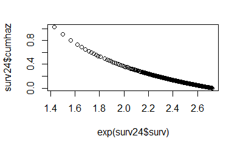

```r
plot(exp(surv24$surv),surv24$cumhaz)
```

```r
cph_fit_chemo = cph(
  Surv(DX_LASTCONTACT_DEATH_MONTHS, PUF_VITAL_STATUS==0) ~
                      AGE+
                      SEX +
                      CDCC_TOTAL_BEST  +
                      TUMOR_SIZE_cat  +
                      GRADE  +
                      Pathology +
                      Visceral_Pleural_Invasion+
                      LYMPH_VASCULAR_INVASION2+
                      Margins  +
                      Lymph_Nodes_Sampled +
                      Excision_less_than1,
                    data = NCDB_lung2, surv = TRUE, x=TRUE, y=TRUE, time.inc=24,subset=Chemo=="Chemo")

cph_fit_nochemo = cph(
  Surv(DX_LASTCONTACT_DEATH_MONTHS, PUF_VITAL_STATUS==0) ~
                      AGE+
                      SEX +
                      CDCC_TOTAL_BEST  +
                      TUMOR_SIZE_cat  +
                      GRADE  +
                      Pathology +
                      Visceral_Pleural_Invasion+
                      LYMPH_VASCULAR_INVASION2+
                      Margins  +
                      Lymph_Nodes_Sampled +
                      Excision_less_than1,
                    data = NCDB_lung2, surv = TRUE, x=TRUE, y=TRUE, time.inc=24,subset=Chemo=="No Chemo")


cph_fit3 = cph(
  Surv(DX_LASTCONTACT_DEATH_MONTHS, PUF_VITAL_STATUS==0) ~  Chemo*(
                      AGE+
                      SEX +
                      CDCC_TOTAL_BEST  +
                      TUMOR_SIZE_cat  +
                      GRADE  +
                      Pathology +
                      Visceral_Pleural_Invasion+
                      LYMPH_VASCULAR_INVASION2+
                      Margins  +
                      Lymph_Nodes_Sampled +
                      Excision_less_than1),
                    data = NCDB_lung2, surv = TRUE, x=TRUE, y=TRUE, time.inc=3)



cph_fit60 = cph(
  Surv(DX_LASTCONTACT_DEATH_MONTHS, PUF_VITAL_STATUS==0) ~  Chemo*(
                      AGE+
                      SEX +
                      CDCC_TOTAL_BEST  +
                      TUMOR_SIZE_cat  +
                      GRADE  +
                      Pathology +
                      Visceral_Pleural_Invasion+
                      LYMPH_VASCULAR_INVASION2+
                      Margins  +
                      Lymph_Nodes_Sampled +
                      Excision_less_than1),
                    data = NCDB_lung2, surv = TRUE, x=TRUE, y=TRUE, time.inc=60)
```

## 17.1 Chemo

```r
med <- Quantile(cph_fit_chemo)
surv <- Survival(cph_fit_chemo)
nom1 <- nomogram(cph_fit_chemo,fun=list(function(x) surv(3, x),
                                  function(x) surv(24, x),
                                  function(x) surv(60, x)),
                funlabel=c("3-Month Survival Probability",
"24-month Survival Probability", "60-month Survival Probability"), adj.to = list(Chemo='Chemo'))
```

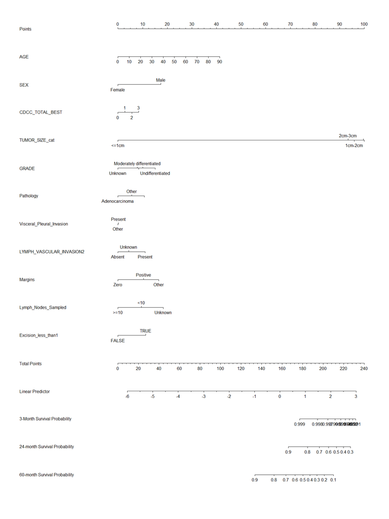

```r
plot(nom1,xfrac=0.4, cex.axis=1, cex.var=1)
```

## 17.2 No Chemo

```r
nom2 <- nomogram(cph_fit_nochemo,fun=list(function(x) surv(3, x),
                                  function(x) surv(24, x),
                                  function(x) surv(60, x)),
                funlabel=c("3-Month Survival Probability",
"24-month Survival Probability", "60-month Survival Probability"), adj.to = list(Chemo='No Chemo'))
```

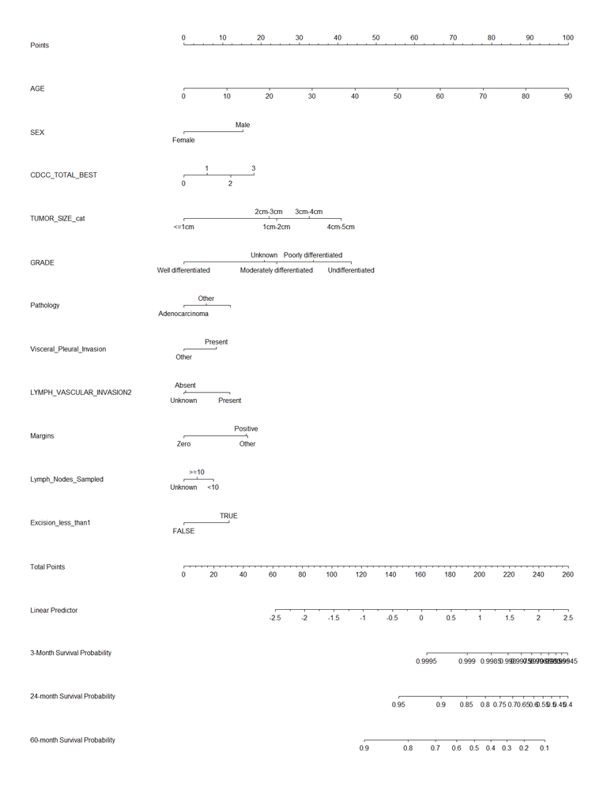

```r
plot(nom2,xfrac=0.4, cex.axis=1, cex.var=1)
```